# SureChEMBL iPython Notebook Tutorial

## An introduction to patent chemoinformatics using SureChEMBL data and the RDKit toolkit

### George Papadatos, ChEMBL group, EMBL-EBI

## In this tutorial:

1. Read a file that contains all chemistry extracted from the Levitra US patent (US6566360) along with *all* the other members of the same patent family.
2. Filter by different text-mining and chemoinformatics properties to remove noise and enrich the genuinely novel structures claimed in the patent documents.
3. Visualise the chemical space using MDS and dimensionality reduction.
1. Identify outliers in the chemistry space.
2. Fix wrongly extracted structures.
4. Find the Murcko and MCS scaffolds of the claimed compounds in the patent family.
1. Compare the derived core with the actual Markush structure as reported in the original patent document.
6. Identify **key** compounds using structural information only. This is based on the publications by [Hattori et al.](http://pubs.acs.org/doi/abs/10.1021/ci7002686) and [Tyrchan et al.](http://pubs.acs.org/doi/abs/10.1021/ci3001293).
1. Count the number of NNs per compound.
2. Perform R-Group decomposition.

```python
import matplotlib.pyplot as plt
import pandas as pd

from IPython.display import display
from IPython.display import display_pretty, display_html, HTML, Javascript, Image

from rdkit.Chem import PandasTools
from rdkit.Chem.Draw import IPythonConsole
from rdkit.Chem import AllChem as Chem
from rdkit.Chem import DataStructs
from rdkit.Chem import MCS
from rdkit.Chem import Draw
Draw.DrawingOptions.elemDict[0]=(0.,0.,0.)  # draw dummy atoms in black

from itertools import cycle
from sklearn import manifold
from scipy.spatial.distance import *

import mpld3
mpld3.enable_notebook()

import warnings
warnings.filterwarnings('ignore')
```

```python
from rdkit import rdBase
rdBase.rdkitVersion
```

```
'2014.03.1'
```

This is the base URL of the publicly accessible [ChEMBL Beaker](https://www.ebi.ac.uk/chembl/api/utils/docs) server.

```python
base_url = 'www.ebi.ac.uk/chembl/api'
```

```python
pd.options.display.mpl_style = 'default'
pd.options.display.float_format = '{:.2f}'.format
```

```python
rcParams['figure.figsize'] = 16,10
```

## 1. Read and filter the input file

The file was generated by extracting all chemistry from a list of patent documents in [SureChEMBL](https://www.surechembl.org). The Lucene query used to retrieve the list of relevant patents was: pn:"US6566360".

```python
df = pd.read_csv('document chemistry_20141011_114421_271.csv',sep=',')
```

Let's check the contents:

```python
df.info()
```

```
<class 'pandas.core.frame.DataFrame'>
Int64Index: 8497 entries, 0 to 8496
Data columns (total 28 columns):
Patent ID                    8497 non-null object
Annotation Reference         8497 non-null object
Chemical ID                  8497 non-null int64
SMILES                       8497 non-null object
Type                         8497 non-null object
Chemical Document Count      8497 non-null int64
Annotation Document Count    3372 non-null float64
Title Count                  3372 non-null float64
Abstract Count               3372 non-null float64
Claims Count                 3372 non-null float64
Description Count            3372 non-null float64
Chemical Corpus Count        8497 non-null int64
Annotation Corpus Count      3372 non-null float64
Molecular Weight             8497 non-null float64
Med Chem Alert               8497 non-null int64
Log P                        8497 non-null float64
Donor Count                  8497 non-null int64
Acceptor Count               8497 non-null int64
Ring Count                   8497 non-null int64
Rotatable Bound Count        8497 non-null int64
Radical                      8497 non-null int64
Fragment                     8497 non-null int64
Connected                    8497 non-null int64
Singleton                    8497 non-null int64
Simple                       8497 non-null int64
Lipinski                     8497 non-null int64
Lead Likeness                8497 non-null int64
Bio Availability             8497 non-null int64
dtypes: float64(8), int64(16), object(4)
```

```python
df.shape
```

```
(8497, 28)
```

Add a SCHEMBL ID column and sort:

```python
df['SCHEMBL ID'] = df['Chemical ID'].map(lambda x: 'SCHEMBL{0}'.format(x))
df = df.sort('Chemical ID')
```

```python
#df.head()
```

**First round of filtering: Novel compounds appear in the description or claims section of the document. Alternatively, they are extracted from images or mol files**

```python
dff = df[(df['Claims Count'] > 0) | (df['Description Count'] > 0) | (df['Type'] != "TEXT")]
```

```python
dff.shape
```

```
(8484, 29)
```

**Second round of filtering: Simple physicochemical properties and counts**

```python
dff = dff[(dff['Rotatable Bound Count'] < 15) & (dff['Ring Count'] > 0) & (df['Radical'] == 0) & (df['Singleton'] == 0) & (df['Simple'] == 0)]
```

```python
dff.shape
```

```
(8218, 29)
```

```python
dff = dff[(dff['Molecular Weight'] >= 300) & (dff['Molecular Weight'] <= 800) & (dff['Log P'] > 0) & (dff['Log P'] < 7)]
```

```python
dff.shape
```

```
(6711, 29)
```

**Third round of filtering: Using Global Corpus Count**

```python
dff = dff[(dff['Chemical Corpus Count'] < 400) & ((dff['Annotation Corpus Count'] < 400) | (dff['Annotation Corpus Count'].isnull()))]
```

```python
dff.shape
```

```
(6459, 29)
```

**Keep largest fragment and convert SMILES to RDKit molecules**

```python
dff['SMILES'] = dff['SMILES'].map(lambda x: max(x.split('.'), key=len))
```

```python
PandasTools.AddMoleculeColumnToFrame(dff, smilesCol = 'SMILES')
```

```python
#dff.head(10)
```

**Fourth round of filtering: Remove duplicates based on Chemical IDs and InChI keys**

```python
dff['InChI'] = dff['ROMol'].map(Chem.MolToInchi)
dff['InChIKey'] = dff['InChI'].map(Chem.InchiToInchiKey)
```

```python
#dff.head()
```

```python
dff = dff.drop_duplicates('Chemical ID')
```

```python
dff.shape
```

```
(401, 32)
```

```python
dff = dff.drop_duplicates('InChIKey')
```

```python
dff.shape
```

```
(394, 32)
```

Wow, that was a lot of duplicates. This is because the same compounds come from different patents in the same patent family. In addition, in US patents a compound may come from 3 different sources: text, image and mol file.

**Fifth round of filtering: Remove Boron-containing compounds as they are likely to be reactants.**

```python
dff = dff.ix[~(dff['ROMol'] >= Chem.MolFromSmarts('[#5]'))]
```

```python
dff.shape
```

```
(394, 32)
```

```python
dff = dff.set_index('Chemical ID', drop=False)
```

That was the end of the filters - let's see a summary of the remaining compounds and their patent document source:

```python
dff_counts = dff[['Patent ID','ROMol']].groupby('Patent ID').count()
```

```python
dff_counts['Link'] = dff_counts.index.map(lambda x: '<a href="https://www.surechembl.org/document/{0}/" target="_blank">{0}</a>'.format(x))
```

```python
dff_counts = dff_counts.rename(columns={'ROMol':'# Compounds'})
```

```python
dff_counts
```

| Patent ID | # Compounds | Link |
| --- | --- | --- |
| EP-1049695-A1 | 2 | [EP-1049695-A1](https://www.surechembl.org/document/EP-1049695-A1/) |
| EP-1049695-B1 | 7 | [EP-1049695-B1](https://www.surechembl.org/document/EP-1049695-B1/) |
| EP-1174431-A2 | 1 | [EP-1174431-A2](https://www.surechembl.org/document/EP-1174431-A2/) |
| EP-2295436-A1 | 68 | [EP-2295436-A1](https://www.surechembl.org/document/EP-2295436-A1/) |
| US-20040067945-A1 | 4 | [US-20040067945-A1](https://www.surechembl.org/document/US-20040067945-A1/) |
| US-20050070541-A1 | 2 | [US-20050070541-A1](https://www.surechembl.org/document/US-20050070541-A1/) |
| US-20060189615-A1 | 2 | [US-20060189615-A1](https://www.surechembl.org/document/US-20060189615-A1/) |
| US-20080113972-A1 | 34 | [US-20080113972-A1](https://www.surechembl.org/document/US-20080113972-A1/) |
| US-20100016323-A1 | 29 | [US-20100016323-A1](https://www.surechembl.org/document/US-20100016323-A1/) |
| US-20110009367-A1 | 43 | [US-20110009367-A1](https://www.surechembl.org/document/US-20110009367-A1/) |
| US-20130059844-A1 | 46 | [US-20130059844-A1](https://www.surechembl.org/document/US-20130059844-A1/) |
| US-6362178-B1 | 6 | [US-6362178-B1](https://www.surechembl.org/document/US-6362178-B1/) |
| US-6566360-B1 | 4 | [US-6566360-B1](https://www.surechembl.org/document/US-6566360-B1/) |
| US-6890922-B2 | 2 | [US-6890922-B2](https://www.surechembl.org/document/US-6890922-B2/) |
| US-7122540-B2 | 7 | [US-7122540-B2](https://www.surechembl.org/document/US-7122540-B2/) |
| US-7314871-B2 | 43 | [US-7314871-B2](https://www.surechembl.org/document/US-7314871-B2/) |
| US-7696206-B2 | 32 | [US-7696206-B2](https://www.surechembl.org/document/US-7696206-B2/) |
| US-7704999-B2 | 59 | [US-7704999-B2](https://www.surechembl.org/document/US-7704999-B2/) |
| WO-1999024433-A1 | 3 | [WO-1999024433-A1](https://www.surechembl.org/document/WO-1999024433-A1/) |

Right, is Levitra included in this set? ChEMBL tells me that its InChiKey is 'SECKRCOLJRRGGV-UHFFFAOYSA-N'.

SCHEMBL ID

ROMol

Chemical ID

5441

SCHEMBL5441

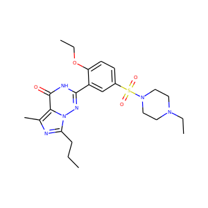

```python
dff.ix[dff.InChIKey == 'SECKRCOLJRRGGV-UHFFFAOYSA-N',['SCHEMBL ID','ROMol']]
```

Good - it is...

## 2. Visualise the patent chemical space - MDS

Preparation of the pairwise distance matrix.

```python
fps = [Chem.GetMorganFingerprintAsBitVect(m,2,nBits=2048) for m in dff['ROMol']]
```

```python
dist_mat = squareform(pdist(fps,'jaccard'))
```

```python
mds = manifold.MDS(n_components=2, dissimilarity="precomputed", random_state=3, n_jobs = 2)
```

```python
results = mds.fit(dist_mat)
```

```python
coords = results.embedding_
```

```python
dff['X'] = [c[0] for c in coords]
```

```python
dff['Y'] = [c[1] for c in coords]
```

```python
csss = """
table
{
  border-collapse: collapse;
}
th
{
  color: #ffffff;
  background-color: #848482;
}
td
{
  background-color: #f2f3f4;
}
table, th, td
{
  font-family:Arial, Helvetica, sans-serif;
  border: 1px solid black;
  text-align: right;
}
"""
```

```python
import base64
```

```python
dff['base64smi'] = dff['SMILES'].map(base64.b64encode)
```

```python
fig, ax = plt.subplots()
fig.set_size_inches(14.0, 12.0)
#colors = cycle('bgrcmykwbgrcmykbgrcmykwbgrcmykw')
colors = cycle(cm.Dark2(np.linspace(0,1,len(dff_counts.index))))
for name, group in dff.groupby('Patent ID'):
    labels = []
    for i in group.index:
        zz = group.ix[[i],['Patent ID','SCHEMBL ID','base64smi']]
        zz['mol'] = zz['base64smi'].map(lambda x: '<img src="https://{0}/utils/smiles2image/{1}/300">'.format(base_url,x))
        del zz['base64smi']
        label = zz.T
        del zz
        label.columns = ['Row: {}'.format(i)]
        labels.append(str(label.to_html()))
    points = ax.scatter(group['X'], group['Y'],c=colors.next(), s=80, alpha=0.8)
    tooltip = mpld3.plugins.PointHTMLTooltip(points, labels, voffset=10, hoffset=10, css=csss)
    mpld3.plugins.connect(fig,tooltip)
```

```python
resmarts = "([R:5][C;!R:1]=[C;H2].[C;H0,H1;!R:4]-[N;H2:2])>>[R:5][*:1]=[*:2]-[*:4]"
```

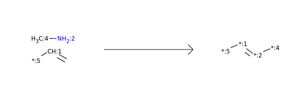

```python
Draw.ReactionToImage(Chem.ReactionFromSmarts(resmarts))
```

```python
def fixRing(mol,resmarts=resmarts):
    rxn = Chem.ReactionFromSmarts(resmarts)
    ps = rxn.RunReactants((mol,))
    if ps:
        m = ps[0][0]
        Chem.SanitizeMol(m)
        return m
    else:
        return mol
```

So this...

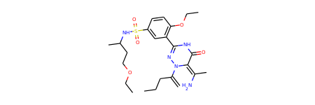

```python
mm = dff.ix[12823029]['ROMol']
mm
```

...will become this:

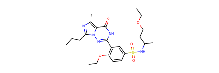

```python
fixRing(mm)
```

Let's apply the repair to all affected structures:

```python
for i, p, m in zip(dff.index, dff['Patent ID'], dff['ROMol']):
    if p == 'EP-2295436-A1':
        dff.ix[i,'ROMol'] = fixRing(m)
```

```python
dff['InChI'] = dff['ROMol'].map(Chem.MolToInchi)
dff['InChIKey'] = dff['InChI'].map(Chem.InchiToInchiKey)
dff = dff.drop_duplicates('InChIKey')
```

So after the fix, we have even less structures because some of the fixed ones already existed. Hopefully, however, we have less false positives too:

```python
dff.shape
```

```
(363, 35)
```

```python
dff['RD_SMILES'] = dff['ROMol'].map(Chem.MolToSmiles)
dff['base64rdsmi'] = dff['RD_SMILES'].map(base64.b64encode)
```

```python
fps = [Chem.GetMorganFingerprintAsBitVect(m,2,nBits=2048) for m in dff['ROMol']]
dist_mat = squareform(pdist(fps,'jaccard'))
mds = manifold.MDS(n_components=2, dissimilarity="precomputed", random_state=3, n_jobs = 2)
results = mds.fit(dist_mat)
coords = results.embedding_
dff['X'] = [c[0] for c in coords]
dff['Y'] = [c[1] for c in coords]
```

```python
fig, ax = plt.subplots()
fig.set_size_inches(14.0, 12.0)
#colors = cycle('bgrcmykwbgrcmykbgrcmykwbgrcmykw')
colors = cycle(cm.Dark2(np.linspace(0,1,len(dff_counts.index))))
for name, group in dff.groupby('Patent ID'):
    labels = []
    for i in group.index:
        zz = group.ix[[i],['Patent ID','SCHEMBL ID','base64rdsmi']]
        zz['mol'] = zz['base64rdsmi'].map(lambda x: '<img src="https://{0}/utils/smiles2image/{1}/300">'.format(base_url,x))
        del zz['base64rdsmi']
        label = zz.T
        del zz
        label.columns = ['Row: {}'.format(i)]
        labels.append(str(label.to_html()))
    points = ax.scatter(group['X'], group['Y'],c=colors.next(), s=80, alpha=0.8)
    tooltip = mpld3.plugins.PointHTMLTooltip(points, labels, voffset=10, hoffset=10, css=csss)
    mpld3.plugins.connect(fig,tooltip)
```

## 3. Define the MCS for this set of claimed molecules

A helper function, inspired by Greg Landrum's post [here](http://rdkit.blogspot.co.uk/2014/02/more-on-datasets-ii.html).

```python
def MCS_Report(ms,atomCompare='any',**kwargs):
    mcs = MCS.FindMCS(ms,atomCompare=atomCompare,timeout=120,**kwargs)
    nAts = np.array([x.GetNumAtoms() for x in ms])
    print 'Mean nAts: {0}, mcs nAts: {1}'.format(nAts.mean(),mcs.numAtoms)
    print 'MCS SMARTS: {0}'.format(mcs.smarts)
    mcsM = Chem.MolFromSmarts(mcs.smarts)
    # find the common atoms
    if atomCompare == 'any':
        mcsM2 = Chem.MolFromSmiles(mcs.smarts,sanitize=False)
        atNums=[-1]*mcsM.GetNumAtoms()
        for m in ms:
            match = m.GetSubstructMatch(mcsM)
            if not match:
                continue
            for qidx,midx in enumerate(match):
                anum = m.GetAtomWithIdx(midx).GetAtomicNum()
                if atNums[qidx]==-1:
                    atNums[qidx]=anum
                elif anum!=atNums[qidx]:
                    atNums[qidx]=0
        for idx,atnum in enumerate(atNums):
            if atnum>0:
                mcsM.GetAtomWithIdx(idx).SetAtomicNum(atnum)

    mcsM.UpdatePropertyCache(False)
    Chem.SetHybridization(mcsM)
    smi = Chem.MolToSmiles(mcsM,isomericSmiles=True)
    print "MCS SMILES: {0}".format(smi)
    img=Draw.MolToImage(mcsM,kekulize=False)
    return mcs.smarts,smi,img,mcsM
```

Let's add the Murcko framework to our data frame:

```python
PandasTools.AddMurckoToFrame(dff)
```

```python
PandasTools.AddMoleculeColumnToFrame(dff,smilesCol='Murcko_SMILES', molCol='MurMol')
```

```python
PandasTools.AlignToScaffold(dff)
```

ROMol

MurMol

Chemical ID

5441

5517

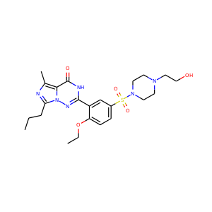

5530

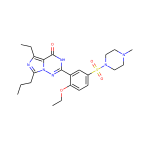

5537

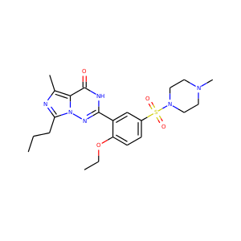

5606

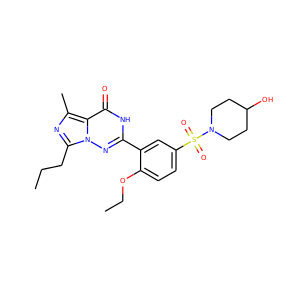

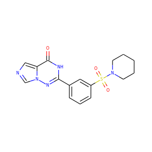

```python
dff[['ROMol','MurMol']].head()
```

And now we'll extract the MCS core:

```
Mean nAts: 24.6914600551, mcs nAts: 16
MCS SMARTS: [*]=!@[*]:1:[*]:[*](:[*]:[*]:2:[*]:[*]:[*]:[*]:1:2)-!@[*]:1:[*]:[*]:[*]:[*]:[*]:1
MCS SMILES: O=C1:N:C(C2:C:C:C:C:C:2):N:N2:C:[*]:C:C:1:2
```

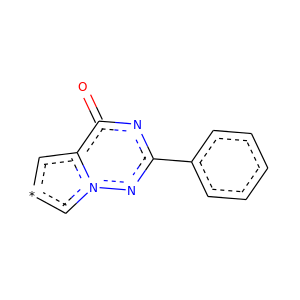

```python
mols = list(dff.MurMol)
smarts,smi,img,mcsM = MCS_Report(mols,threshold=0.8,ringMatchesRingOnly=True)
img
```

## 4. Compare the extracted MCS core with the actual claimed Markush structure.

Given the MCS core, we'll do an R-Group decomposition first to define the R-Groups and their attachement points.

```python
core = Chem.MolFromSmarts(smarts)
```

```python
pind = []
rgroups = []
for i, m in zip(dff.index, dff.ROMol):
    rgrps = Chem.ReplaceCore(m,core,labelByIndex=True)
    if rgrps:
        s = Chem.MolToSmiles(rgrps, True)
        for e in s.split("."):
            pind.append(e[1:4].replace('*','').replace(']',''))
            rgroups.append(e)
        #print "R-Groups: ", i, s
```

```python
pind = sorted(list(set(pind)),key=int)
```

```python
pind = map(int,pind)
```

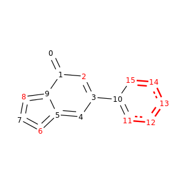

```python
Draw.MolToImage(core,includeAtomNumbers=True,highlightAtoms=pind)
```

## 5. Identify key compounds - in this case, vardenafil itself

This is based on the publication by [Hattori et al.](http://pubs.acs.org/doi/abs/10.1021/ci7002686) and [Tyrchan et al.](http://pubs.acs.org/doi/abs/10.1021/ci3001293). First we'll try the Hattori et al. version of finding the compounds with the highest number of nearest neighbours (NNs) for a given similarity threshold. We will need to calculate the similarity matrix.

```python
sim_mat = []
CUTOFF = 0.8
for i,fp in enumerate(fps):
    tt = DataStructs.BulkTanimotoSimilarity(fps[i],fps)
    for i,t in enumerate(tt):
        if tt[i] < CUTOFF:
            tt[i] = None
    sim_mat.append(tt)
sim_mat=numpy.array(sim_mat)
```

```python
sim_df = pd.DataFrame(sim_mat, columns = dff['Chemical ID'], index=dff['Chemical ID'])
```

```python
sim_df.head()
```

| Chemical ID | 5441 | 5517 | 5530 | 5537 | 5606 | 5613 | 5673 | 12070 | 13527 | 13579 | 13598 | 13607 | 13631 | 13694 | 13812 | 13825 | 13848 | 14279 | 972506 | 972565 | 972730 | 973032 | 973183 | 973241 | 973332 | 973348 | 973349 | 973382 | 973386 | … |
| --- | --- | --- | --- | --- | --- | --- | --- | --- | --- | --- | --- | --- | --- | --- | --- | --- | --- | --- | --- | --- | --- | --- | --- | --- | --- | --- | --- | --- | --- | --- |
| 5441 | 1.00 | 0.86 | None | 0.87 | 0.80 | None | None | None | None | None | None | None | None | 0.87 | None | None | None | None | None | None | 0.83 | None | None | None | None | None | None | None | None | … |
| 5517 | 0.86 | 1.00 | None | 0.84 | None | None | None | None | None | None | None | None | None | None | None | None | None | None | None | None | 0.92 | None | None | None | None | None | None | None | None | … |
| 5530 | None | None | 1.00 | 0.84 | None | None | None | None | None | None | None | None | None | None | None | None | None | None | None | None | None | None | None | None | None | None | None | None | None | … |
| 5537 | 0.87 | 0.84 | 0.84 | 1.00 | 0.81 | None | None | None | None | None | None | 0.81 | None | None | None | None | None | None | None | None | 0.82 | None | None | None | None | None | None | None | None | … |
| 5606 | 0.80 | None | None | 0.81 | 1.00 | None | None | None | None | None | None | None | None | None | None | None | None | None | 0.90 | None | None | None | None | None | None | None | None | None | None | … |

```python
d = sim_df.count().to_dict()
nn_df = pd.DataFrame(d.items(),columns=['Chemical ID', '# NNs'])
nn_df.set_index('Chemical ID',inplace=True)
nn_df.head()
```

| Chemical ID | # NNs |
| --- | --- |
| 975193 | 5 |
| 974886 | 3 |
| 1456170 | 1 |
| 12822592 | 2 |
| 12822595 | 1 |

Chemical ID

ROMol

# NNs

Chemical ID

12823654

12823654

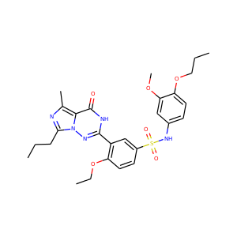

23

5441

5441

22

12824064

12824064

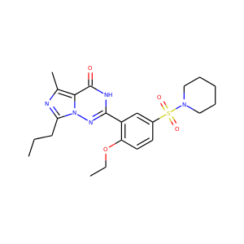

21

5537

5537

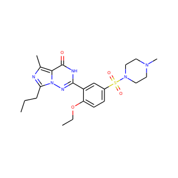

21

12822873

12822873

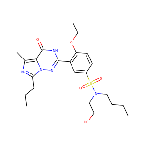

18

```python
pd.merge(dff[['Chemical ID','ROMol']],nn_df,left_index=True, right_index=True, sort=False).sort('# NNs',ascending=False).head()
```

So, the method seems to be working in this case. Vardenafil has the second largest number of NNs with a cutoff of 0.8. Next, we'll try one of the Tyrchan et al. methods (Frequency of Groups, FOG) and count the frequency of the derived R-Groups:

```python
from collections import Counter
rgroups = [r.replace('[15*]','[11*]').replace('[14*]','[12*]') for r in rgroups]
c = Counter(rgroups)
```

```python
rgroup_counts = pd.DataFrame(c.most_common(20),columns=['RGroups','Frequency'])
rgroup_counts.head(10)
```

|  | RGroups | Frequency |
| --- | --- | --- |
| 0 | [6*]CCC | 349 |
| 1 | [11*]OCC | 306 |
| 2 | [8*]C | 294 |
| 3 | [8*]CC | 63 |
| 4 | [11*]OCCC | 28 |
| 5 | [11*]O | 16 |
| 6 | [6*]C | 10 |
| 7 | [12*]S(=O)(=O)N1CCN(C)CC1 | 8 |
| 8 | [13*]OC | 8 |
| 9 | [12*]S(=O)(=O)N(CC)CCO | 7 |

RGroups

Frequency

ROMol

0

[6*]CCC

349

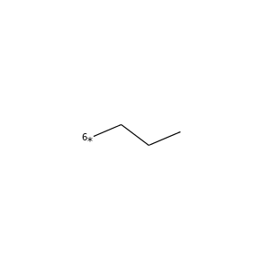

1

[11*]OCC

306

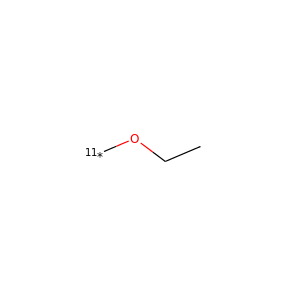

2

[8*]C

294

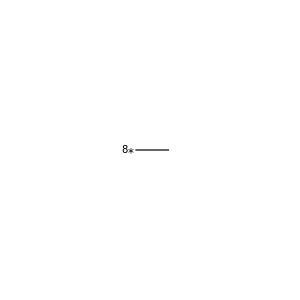

3

[8*]CC

63

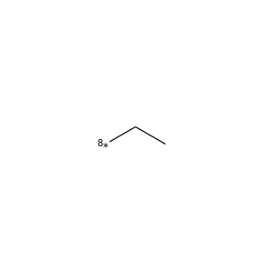

4

[11*]OCCC

28

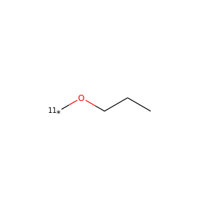

5

[11*]O

16

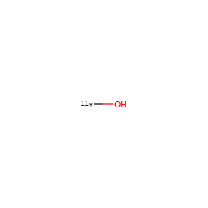

6

[6*]C

10

7

[12*]S(=O)(=O)N1CCN(C)CC1

8

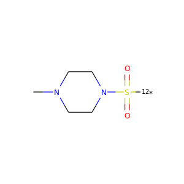

8

[13*]OC

8

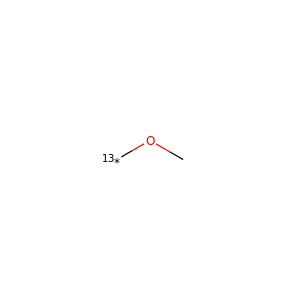

9

[12*]S(=O)(=O)N(CC)CCO

7

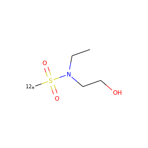

```python
PandasTools.AddMoleculeColumnToFrame(rgroup_counts, smilesCol = 'RGroups')
rgroup_counts.head(10)
```